# Week 1 Take Home Lab

Sam Fritz-Schreck

2024-01-08

## Week 4 Take-Home Lab Assignment

Rudy Yoshida

###Introduction

For this week’s take-home lab, you’ll solve the very same problem studied in this week’s in-class lab on a much larger and more interesting dataset. The data contained in the file UCI_Credit_Card.csv contains 30,000 consumer records with 24 different variables. You can read a detailed description of the different fields at the following website: https://archive.ics.uci.edu/ml/datasets/default+of+credit+card+clients The description from the UCI says marriage should have levels: Marital status (1 = married; 2 = single; 3 = others) However, there are levels (0,1,2,3). You should treat 0 as unknown. the description from the UCI says Education (1 = graduate school; 2 = university; 3 = high school; 4 = others). However, there are levels 1 to 6 for education. Thus here 5 = 6 = unknow. X6-X11: The measurement scale for the repayment status is: -1 = pay duly; 1 = payment delay for one month; 2 = payment delay for two months; . . .; 8 = payment delay for eight months; 9 = payment delay for nine months and above. However, there are many factors that are -2. This is also unknown. So every unknown you should treat them as NA.

Your task is to build the best possible model for predicting whether or not a consumer will default on their credit card payment for the next month (the last column in the dataset).

Perform the following tasks:

Conduct a training/test split of the data, building a 20% held out test dataset

Fit the best logistic regression model you can (consider feature selection etc.) to the data to predict consumer default. Make sure that all predictors are standardized by the scale() function.

### Data Cleaning/EDA

```r
Default = read.csv('UCI_Credit_Card.csv', header = T)

#Default$EDUCATION[Default$EDUCATION == 1] = 2
#Default$EDUCATION[Default$EDUCATION == 2] = 'University'
#Default$EDUCATION[Default$EDUCATION == 3] = 'High_School'
#Default$EDUCATION[Default$EDUCATION == 4] = 'Other'
Default$EDUCATION[Default$EDUCATION == 5] = NA
Default$EDUCATION[Default$EDUCATION == 6] = NA
Default$EDUCATION[Default$EDUCATION == 0] = NA

Default$MARRIAGE[Default$MARRIAGE == 0] = NA
#Default$MARRIAGE[Default$MARRIAGE == 1] = 'Married'
#Default$MARRIAGE[Default$MARRIAGE == 2] = 'Single'
#Default$MARRIAGE[Default$MARRIAGE == 3] = 'Other'

Default[,6:11][Default[,6:11] == 2] = 1
Default[,6:11][Default[,6:11] >= 3] = 2
Default[,6:11][Default[,6:11] == -2] = NA
#Default[,6:11][Default[,6:11] == -1] = 0

summary(Default)

Default$default.payment.next.month = factor(Default$default.payment.next.month, levels = c(0,1), labels = c('No','Yes'))
Default$SEX = factor(Default$SEX)
Default$EDUCATION = factor(Default$EDUCATION)
Default$MARRIAGE = factor(Default$MARRIAGE)
for (x in 6:11){
  Default[,x] = factor(Default[,x])
}
Default_scale = Default
Default_scale[,c(1,5,12:23)] = scale(Default[,c(1,5,12:23)])
#remove payment observations more than 52 sd from mean
Default_scale = subset(Default_scale, Default_scale$PAY_AMT1<=52 & Default_scale$PAY_AMT2<=52 & Default_scale$PAY_AMT3<=52& Default_scale$PAY_AMT4<=52& Default_scale$PAY_AMT5<=52& Default_scale$PAY_AMT6<=52)

Default.na_omit = na.omit(Default_scale)
#K1 = kmeans(Default.na_omit[,c(12:23)],4,nstart=25)
#Default.na_omit$PayCluster = K1$cluster
#fviz_cluster(K1, data = Default.na_omit[,c(12:23)])
#Default.na_omit = Default.na_omit[,-c(12:23)]
summary(Default.na_omit)
```

### Data Imputation

```r
pMiss <- function(x){sum(is.na(x))/length(x)*100}

apply(Default,2,pMiss)

library(VIM)
aggr_plot <- aggr(Default, col=c('navyblue','red'), numbers=TRUE, sortVars=TRUE, labels=names(Default), cex.axis=.7, gap=3, ylab=c("Histogram of missing data","Pattern"))


imp <- mice(Default_scale, maxit = 2, m = 2, seed = 1)
Default_imp = complete(imp)

# inspect quality of imputations
stripplot(imp, MARRIAGE, pch = 19, xlab = "Imputation number")
stripplot(imp, EDUCATION, pch = 19, xlab = "Imputation number")

library(ggplot2)
# Basic box plot
base <- ggplot(Default, aes(x=MARRIAGE, y=LIMIT_BAL)) +
  geom_boxplot()
base

imput <- ggplot(Default_imp, aes(x=MARRIAGE, y=LIMIT_BAL)) +
  geom_boxplot()
imput

Default_imp_nopay = Default_imp[, -c(6:11)]
```

* Don’t include payment status as a predictor? *

```r
## Plot the actual data
plotData <- ggplot(data = Default,
       mapping = aes(x = LIMIT_BAL, y = AGE, color = as.factor(default.payment.next.month), shape = MARRIAGE)) +
    layer(geom = "point", stat = "identity", position = "identity") +
    scale_color_manual(values = c('0' = "blue", '1' = "red")) +
    theme_bw() +
    theme(legend.key = element_blank()) +
    labs(title = "Original data")
plotData
```

### Logit Modelling

```r
set.seed(547)  # ensures we all get the sample sample of data for train/test

sampler.na_omit <- sample(nrow(Default.na_omit),trunc(nrow(Default.na_omit)*.80)) # samples index
sampler.imp <- sample(nrow(Default_imp),trunc(nrow(Default_imp)*.80)) # samples index

na_omit.Train <- Default.na_omit[sampler.na_omit,]
na_omit.Test <- Default.na_omit[-sampler.na_omit,]

imp.Train <- Default_imp[sampler.imp,]
imp.Test <- Default_imp[-sampler.imp,]

Logit.na_omit <- glm(formula = default.payment.next.month ~ .,
               family  = binomial(link = "logit"),
               data    = na_omit.Train)
summary(Logit.na_omit)

Logit.imp <- glm(formula = default.payment.next.month ~ .,
               family  = binomial(link = "logit"),
               data    = imp.Train)
summary(Logit.imp)
```

```r
# Conduct stepwise model selection
Logit.step.na_omit<-step(Logit.na_omit, direction = "both")

Logit.step.imp<-step(Logit.imp, direction = "both")

# Summarize the selected model
summary(Logit.step.na_omit)

summary(Logit.step.imp)
```

```r
# Put the predicted probability and class (at 0.5 threshold) at the end of the dataframe
predProbLogit.na_omit <- predict(Logit.step.na_omit, type = "response", newdata = na_omit.Test)
predClassLogit.na_omit <- factor(predict(Logit.step.na_omit, type = "response", newdata=na_omit.Test) > 0.45, levels = c(FALSE,TRUE), labels = c("No","Yes"))

# Create a plotting version of the Default dataset where we will store model predictions
na_omit.Test.Plotting <- na_omit.Test

# Put the predicted probability and class (at 0.5 threshold) at the end of the plotting dataframe
na_omit.Test.Plotting$predProbLogit <- predProbLogit.na_omit
na_omit.Test.Plotting$predClassLogit <- predClassLogit.na_omit

summary(na_omit.Test.Plotting)  # look at a summary of the updated data frame

# Put the predicted probability and class (at 0.5 threshold) at the end of the dataframe
predProbLogit.imp <- predict(Logit.step.imp, type = "response", newdata = imp.Test)
predClassLogit.imp <- factor(predict(Logit.step.imp, type = "response", newdata=imp.Test) > 0.45, levels = c(FALSE,TRUE), labels = c("No","Yes"))

# Create a plotting version of the Default dataset where we will store model predictions
imp.Test.Plotting <- imp.Test

# Put the predicted probability and class (at 0.5 threshold) at the end of the plotting dataframe
imp.Test.Plotting$predProbLogit <- predProbLogit.imp
imp.Test.Plotting$predClassLogit <- predClassLogit.imp

#summary(imp.Test.Plotting)  # look at a summary of the updated data frame
```

```r
# Generate a confusion matrix and performance statistics on test dataset
confusionMatrix(data=predClassLogit.na_omit, reference=na_omit.Test$default.payment.next.month)

confusionMatrix(data=predClassLogit.imp, reference=imp.Test$default.payment.next.month)
```

```r
# Calculate AUC - use @y.values to get AUC out
Logit.AUC.na_omit <- performance(prediction(predProbLogit.na_omit, na_omit.Test$default.payment.next.month), measure="auc")@y.values
Logit.AUC.na_omit

Logit.AUC.imp <- performance(prediction(predProbLogit.imp, imp.Test$default.payment.next.month), measure="auc")@y.values
Logit.AUC.imp
```

### Assignment Questions

Provide a summary and discussion of your work in written form (.docx or .pdf) that includes the following:

Q1 Summarize the model/feature selection process you used to fit your logistic regression model

I started with just cleaning the raw data and converting values to NA that needed to be. I also converted the sex, education, and marriage predictors and the default response to factors. Then, I scaled the remaining predictors and removed NAs to create a dataset to compare against imputation of NAs. Once I had these two datasets, I split them 80/20 into training and test sets. This resulted in roughly 0.77 AUC for the omitted data and 0.74 for the imputted data.

After seeing that the PAY_* predictors playing a significant role, I decided to try to incorporate them as a categorical predictor rather than numerical. Following issues with factors showing in the test set that were not in the training set, I decided to reduce the dimensionality by keeping -1 (pay duly) and 0 (pay on time but not in full) as their own categories, 1 month late and 2 months late as the same category, and 3 or more months late as the same category. This brought the performance up to about 0.79 and 0.76 AUC respectively.

Finally, I identified three outliers within the PAY_AMT* predictors that were more than 50 SD from the mean payment within that month so I removed them from both datasets. This resulted in 0.81 and 0.77 respectively, the best performance achieved for this model. Both models are summarized below.

Most of the effort was put into the cleaning and munging of the data allowing the step function to select a good performing model. This effort will likely make our future model fitting and comparison easier.

Q2 Provide a summary of the fitted logistic regression model (i.e. model summary)

```r
summary(Logit.step.na_omit)
```

```
##
## Call:
## glm(formula = default.payment.next.month ~ LIMIT_BAL + SEX +
##     EDUCATION + MARRIAGE + PAY_0 + PAY_2 + PAY_3 + PAY_4 + PAY_5 +
##     PAY_6 + BILL_AMT1 + BILL_AMT2 + BILL_AMT3 + PAY_AMT1 + PAY_AMT2 +
##     PAY_AMT5, family = binomial(link = "logit"), data = na_omit.Train)
##
## Coefficients:
##              Estimate Std. Error z value Pr(>|z|)
## (Intercept)  -1.33832    0.07292 -18.352  < 2e-16 ***
## LIMIT_BAL    -0.37735    0.03153 -11.968  < 2e-16 ***
## SEX2         -0.12680    0.03991  -3.177 0.001488 **
## EDUCATION2    0.02521    0.04743   0.532 0.595039
## EDUCATION3   -0.02693    0.06148  -0.438 0.661283
## EDUCATION4  -12.74423  109.20207  -0.117 0.907095
## MARRIAGE2    -0.19609    0.04110  -4.771 1.83e-06 ***
## MARRIAGE3     0.04571    0.17492   0.261 0.793841
## PAY_00       -1.07974    0.08776 -12.303  < 2e-16 ***
## PAY_01        0.93140    0.08194  11.366  < 2e-16 ***
## PAY_02        1.46784    0.15886   9.240  < 2e-16 ***
## PAY_20        0.59009    0.10709   5.510 3.58e-08 ***
## PAY_21        0.05307    0.10367   0.512 0.608693
## PAY_22       -0.27868    0.16803  -1.659 0.097206 .
## PAY_30        0.03703    0.10517   0.352 0.724810
## PAY_31        0.44798    0.10775   4.158 3.21e-05 ***
## PAY_32        0.28372    0.19187   1.479 0.139215
## PAY_40        0.02143    0.09560   0.224 0.822624
## PAY_41        0.36648    0.10996   3.333 0.000860 ***
## PAY_42        0.08429    0.22087   0.382 0.702732
## PAY_50        0.02453    0.09160   0.268 0.788863
## PAY_51        0.27099    0.11393   2.378 0.017384 *
## PAY_52        0.02716    0.22712   0.120 0.904810
## PAY_60       -0.26819    0.08421  -3.185 0.001448 **
## PAY_61        0.16104    0.10176   1.583 0.113504
## PAY_62        0.50623    0.21183   2.390 0.016857 *
## BILL_AMT1    -0.15933    0.10656  -1.495 0.134857
## BILL_AMT2     0.22758    0.12959   1.756 0.079069 .
## BILL_AMT3     0.17887    0.08539   2.095 0.036201 *
## PAY_AMT1     -0.15948    0.04107  -3.883 0.000103 ***
## PAY_AMT2     -0.19725    0.05924  -3.330 0.000869 ***
## PAY_AMT5     -0.06169    0.03252  -1.897 0.057795 .
## ---
## Signif. codes:  0 '***' 0.001 '**' 0.01 '*' 0.05 '.' 0.1 ' ' 1
##
## (Dispersion parameter for binomial family taken to be 1)
##
##     Null deviance: 20078  on 18517  degrees of freedom
## Residual deviance: 16402  on 18486  degrees of freedom
## AIC: 16466
##
## Number of Fisher Scoring iterations: 13
```

```r
summary(Logit.step.imp)
```

```
##
## Call:
## glm(formula = default.payment.next.month ~ LIMIT_BAL + SEX +
##     EDUCATION + MARRIAGE + AGE + PAY_0 + PAY_2 + PAY_3 + PAY_4 +
##     PAY_5 + PAY_6 + BILL_AMT2 + PAY_AMT1 + PAY_AMT2 + PAY_AMT4 +
##     PAY_AMT5 + PAY_AMT6, family = binomial(link = "logit"), data = imp.Train)
##
## Coefficients:
##             Estimate Std. Error z value Pr(>|z|)
## (Intercept) -1.55201    0.06275 -24.734  < 2e-16 ***
## LIMIT_BAL   -0.30288    0.02459 -12.315  < 2e-16 ***
## SEX2        -0.14701    0.03577  -4.110 3.96e-05 ***
## EDUCATION2   0.03279    0.04143   0.792 0.428590
## EDUCATION3  -0.03370    0.05527  -0.610 0.542079
## EDUCATION4  -0.81499    0.40695  -2.003 0.045213 *
## MARRIAGE2   -0.14243    0.04028  -3.536 0.000406 ***
## MARRIAGE3    0.12753    0.15597   0.818 0.413555
## AGE          0.04400    0.01998   2.202 0.027654 *
## PAY_00      -1.23067    0.07388 -16.658  < 2e-16 ***
## PAY_01       0.77738    0.05903  13.169  < 2e-16 ***
## PAY_02       1.33180    0.14073   9.464  < 2e-16 ***
## PAY_20       0.73922    0.08499   8.697  < 2e-16 ***
## PAY_21       0.22099    0.07481   2.954 0.003138 **
## PAY_22      -0.13138    0.13637  -0.963 0.335364
## PAY_30       0.01619    0.07810   0.207 0.835732
## PAY_31       0.42731    0.07809   5.472 4.44e-08 ***
## PAY_32       0.16489    0.15742   1.047 0.294876
## PAY_40       0.06547    0.07076   0.925 0.354864
## PAY_41       0.35626    0.08308   4.288 1.80e-05 ***
## PAY_42       0.17243    0.19447   0.887 0.375247
## PAY_50       0.15793    0.06858   2.303 0.021293 *
## PAY_51       0.39866    0.09016   4.422 9.80e-06 ***
## PAY_52       0.27934    0.19925   1.402 0.160933
## PAY_60      -0.23558    0.06196  -3.802 0.000144 ***
## PAY_61       0.25129    0.08060   3.118 0.001823 **
## PAY_62       0.43887    0.18929   2.318 0.020426 *
## BILL_AMT2    0.23172    0.02437   9.508  < 2e-16 ***
## PAY_AMT1    -0.20087    0.04005  -5.015 5.29e-07 ***
## PAY_AMT2    -0.21060    0.05234  -4.024 5.72e-05 ***
## PAY_AMT4    -0.03730    0.02636  -1.415 0.157171
## PAY_AMT5    -0.03978    0.02532  -1.571 0.116149
## PAY_AMT6    -0.04547    0.02556  -1.779 0.075246 .
## ---
## Signif. codes:  0 '***' 0.001 '**' 0.01 '*' 0.05 '.' 0.1 ' ' 1
##
## (Dispersion parameter for binomial family taken to be 1)
##
##     Null deviance: 25277  on 23996  degrees of freedom
## Residual deviance: 20985  on 23964  degrees of freedom
## AIC: 21051
##
## Number of Fisher Scoring iterations: 6
```

For both datasets, we see that the history of payments plays a critical role in predicting defaults.

Q3 Provide performance evaluation of the fitted logistic regression model using confusion matrix.

```r
# Generate a confusion matrix and performance statistics on test dataset
confusionMatrix(data=predClassLogit.na_omit, reference=na_omit.Test$default.payment.next.month)
```

```
## Confusion Matrix and Statistics
##
##           Reference
## Prediction   No  Yes
##        No  3320  547
##        Yes  251  512
##
##                Accuracy : 0.8276
##                  95% CI : (0.8165, 0.8384)
##     No Information Rate : 0.7713
##     P-Value [Acc > NIR] : < 2.2e-16
##
##                   Kappa : 0.4582
##
##  Mcnemar's Test P-Value : < 2.2e-16
##
##             Sensitivity : 0.9297
##             Specificity : 0.4835
##          Pos Pred Value : 0.8585
##          Neg Pred Value : 0.6710
##              Prevalence : 0.7713
##          Detection Rate : 0.7171
##    Detection Prevalence : 0.8352
##       Balanced Accuracy : 0.7066
##
##        'Positive' Class : No
##
```

```r
confusionMatrix(data=predClassLogit.imp, reference=imp.Test$default.payment.next.month)
```

```
## Confusion Matrix and Statistics
##
##           Reference
## Prediction   No  Yes
##        No  4304  803
##        Yes  335  558
##
##                Accuracy : 0.8103
##                  95% CI : (0.8002, 0.8202)
##     No Information Rate : 0.7732
##     P-Value [Acc > NIR] : 1.279e-12
##
##                   Kappa : 0.3845
##
##  Mcnemar's Test P-Value : < 2.2e-16
##
##             Sensitivity : 0.9278
##             Specificity : 0.4100
##          Pos Pred Value : 0.8428
##          Neg Pred Value : 0.6249
##              Prevalence : 0.7732
##          Detection Rate : 0.7173
##    Detection Prevalence : 0.8512
##       Balanced Accuracy : 0.6689
##
##        'Positive' Class : No
##
```

For both, the sensitivity is similar but the specificity of the imputed data set is lower resulting in lower performance.

Q4 How well do you think the fitted logistic regression model to this dataset works?

Surprisingly, just omitting NAs resulted in the best performance compared to imputation. I think this is due to the number of missing values (roughly 15%) which dilutes the critical PAY_* predictors too much.

Submission Instructions

For this weekly lab assignment, you should submit:

An R script file (or Rmd file)

A written summary/discussion of your work (as discussed above) in .docx or .pdf format.

If you want to just summarize in a single Rmd file, please make sure you write your answer very clearly.

## Week 5 Take-Home Lab Assignment

Rudy Yoshida

Introduction

For this week’s take-home lab, you will work on the same data set from Week 4 Take-Home Lab. You will solve the very same problem studied in this week’s in-class lab on a much larger and more interesting dataset. The data contained in the file UCI_Credit_Card.csv contains 30,000 consumer records with 24 different variables. You can read a detailed description of the different fields at the following website: https://archive.ics.uci.edu/ml/datasets/default+of+credit+card+clients The description from the UCI says marriage should have levels: Marital status (1 = married; 2 = single; 3 = others) However, there are levels (0,1,2,3). You should treat 0 as unknown. the description from the UCI says Education (1 = graduate school; 2 = university; 3 = high school; 4 = others). However, there are levels 1 to 6 for education. Thus here 5 = 6 = unknow. X6-X11: The measurement scale for the repayment status is: -1 = pay duly; 1 = payment delay for one month; 2 = payment delay for two months; . . .; 8 = payment delay for eight months; 9 = payment delay for nine months and above. However, there are many factors that are -2. This is also unknown. So every unknown you should treat them as NA.

Your task is to build the best possible model for predicting whether or not a consumer will default on their credit card payment for the next month (the last column in the dataset).

Perform the following tasks:

Conduct a training/test split of the data, building a 20% held out test dataset

Fit the best SVM model you can (consider feature selection etc.) to the data to predict consumer default.

Then plot ROC curves for the logistic regression and SVM and compare their performance.

Compute the AUC for the logistic regression and SVM and compare their performance.

```r
# Set a seed value so get same answer each time we fit
set.seed(123)

# Balance data using weights
## SVM performs poorly when the data set is not balanced.
wts <- 100/table(Default$default.payment.next.month)

# Apply SVM model using linear kernel having default target and rest three as predictors
 SVM.na_omit <- svm(default.payment.next.month ~ .,data=na_omit.Train, kernel="linear",
             cost=1,gamma=1, class.weight=wts,
             probability=TRUE, decision.values=TRUE)
 SVM.imp <- svm(default.payment.next.month ~ .,data=imp.Train, kernel="linear",
             cost=1,gamma=1, class.weight=wts,
             probability=TRUE, decision.values=TRUE)
summary(SVM.na_omit)
summary(SVM.imp)
```

```r
# Get the probabilities predicted by SVM
predProbSVM.raw.na_omit <-predict(SVM.na_omit, na_omit.Test, probability = TRUE)

# Get the probabilitiy of "Yes" from the attributes
predProbSVM.na_omit <- attributes(predProbSVM.raw.na_omit)$probabilities[,2]

# Get the probability classes
predClassSVM.na_omit <- predict(SVM.na_omit, newdata = na_omit.Test)

# Attach to our plotting dataframe
na_omit.Test.Plotting$predProbSVM.na_omit  <- predProbSVM.na_omit
na_omit.Test.Plotting$predClassSVM.na_omit <- predClassSVM.na_omit

# Get the probabilities predicted by SVM
predProbSVM.raw.imp <-predict(SVM.imp, imp.Test, probability = TRUE)

# Get the probabilitiy of "Yes" from the attributes
predProbSVM.imp <- attributes(predProbSVM.raw.imp)$probabilities[,2]

# Get the probability classes
predClassSVM.imp <- predict(SVM.imp, newdata = imp.Test)

# Attach to our plotting dataframe
imp.Test.Plotting$predProbSVM.imp  <- predProbSVM.imp
imp.Test.Plotting$predClassSVM.imp <- predClassSVM.imp
```

```r
# Report confusion matrix from SVM model for comparison
confusionMatrix(predClassSVM.na_omit, na_omit.Test$default.payment.next.month)
confusionMatrix(predClassSVM.imp, imp.Test$default.payment.next.month)
```

### SVM Tuning

```r
# Balance data using weights from training dataset
wts <- 100/table(na_omit.Train$default)

# Now we build a tuned SVM model using the tune function
# Note this code is commented out due to long model fitting time
set.seed(123)
SVM.Tuned=tune(svm, default.payment.next.month~., data=na_omit.Train, kernel="linear", probability = TRUE,
             class.weight=wts,  ranges=list(cost=c(0.1,1,10),
             gamma=c(0.5,1,2)))

SVM.Tuned # prints report about SVM.Tuned
# This code loads the model fit using the code above that is saved into your css_data file
# Take note of this feature - we are loading a previously fit model stored as an .RData file
# load("SVM.RData")  # loads model data file saved by instructor
# Now extract the best model
SVM.Best<-SVM.Tuned$best.model
```

```r
# Calculate tuned model performance on the test dataset
predClassSVMBest=predict(SVM.Best, na_omit.Test)

# Report confusion matrix from on the test dataset
confusionMatrix(predClassSVMBest, na_omit.Test$default.payment.next.month)

# Get the probabilities predicted by SVM
predProbSVM.raw.na_omit <-predict(SVM.Best, na_omit.Test, probability = TRUE)

# Get the probabilitiy of "Yes" from the attributes
predProbSVM.na_omit <- attributes(predProbSVM.raw.na_omit)$probabilities[,2]

# Calculate ROC statistics for our best logit model
Logit.ROC <- performance(prediction(predProbLogit.na_omit, na_omit.Test$default.payment.next.month), measure="tpr", x.measure="fpr")

SVM.ROC <- performance(prediction(predProbSVM.na_omit, na_omit.Test$default.payment.next.month), measure="tpr", x.measure="fpr")

SVM.AUC.na_omit <- performance(prediction(predProbSVM.na_omit, na_omit.Test$default.payment.next.month), measure="auc")@y.values
```

### Assignment Questions

Provide a summary and discussion of your work in written form (.docx or .pdf) that includes the following:

Q1 Summarize the model/feature selection process you used to fit your SVM model.

I fit an un-tuned SVM on both the omitted and the imputted data. After seeing that the performance was again better on the omitted data, I chose to only tune that SVM due to the amount of time the tuning process takes.

Q2 Provide a summary of the fitted SVM model (i.e. model summary)

```r
summary(SVM.Best)
```

```
##
## Call:
## best.tune(METHOD = svm, train.x = default.payment.next.month ~ .,
##     data = na_omit.Train, ranges = list(cost = c(0.1, 1, 10), gamma = c(0.5,
##         1, 2)), kernel = "linear", probability = TRUE, class.weight = wts)
##
##
## Parameters:
##    SVM-Type:  C-classification
##  SVM-Kernel:  linear
##        cost:  0.1
##
## Number of Support Vectors:  13305
##
##  ( 10213 3092 )
##
##
## Number of Classes:  2
##
## Levels:
##  No Yes
```

Best cost value of the three tested was 0.1 with approx 13000 support vectors.

Q3 Provide performance evaluation of the fitted SVM model using confusion matrix.

```r
confusionMatrix(predClassSVMBest, na_omit.Test$default.payment.next.month)
```

```
## Confusion Matrix and Statistics
##
##           Reference
## Prediction   No  Yes
##        No  3137  434
##        Yes  434  625
##
##                Accuracy : 0.8125
##                  95% CI : (0.801, 0.8237)
##     No Information Rate : 0.7713
##     P-Value [Acc > NIR] : 4.649e-12
##
##                   Kappa : 0.4686
##
##  Mcnemar's Test P-Value : 1
##
##             Sensitivity : 0.8785
##             Specificity : 0.5902
##          Pos Pred Value : 0.8785
##          Neg Pred Value : 0.5902
##              Prevalence : 0.7713
##          Detection Rate : 0.6775
##    Detection Prevalence : 0.7713
##       Balanced Accuracy : 0.7343
##
##        'Positive' Class : No
##
```

Compared to the best Logit model, the tuned SVM has lower sensitivity but higher specificity. Looking at the the matrix, it does a better job classifying people that actually default. (625 vs 512)

Q4 How well do you think the fitted SVM model to this dataset works?

Following tuning, we see similar but slightly lower performance as compared to the Logit model. Both in performance and computation time, Logit is the preferred model thus far.

Q5 Using ROC curves and AUC, which one of logistic regression and SVM works better with the dataset so far?

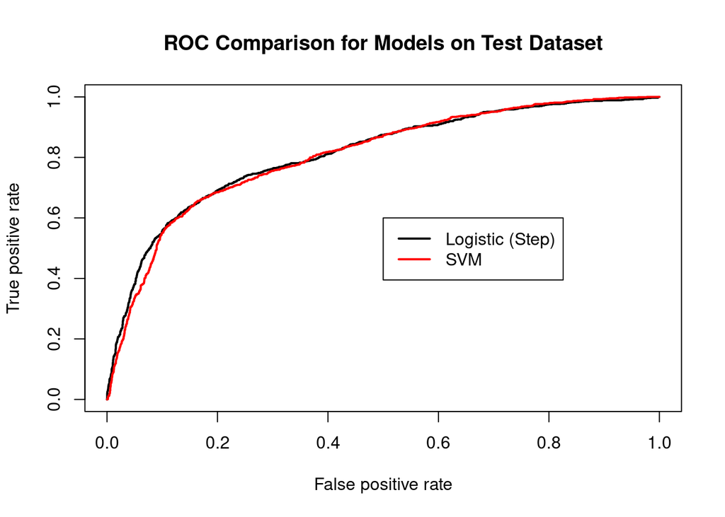

```r
### Plot our ROC Performance with Logit as base
plot(Logit.ROC, lwd=2, main = "ROC Comparison for Models on Test Dataset")

# Add SVM
lines(attributes(SVM.ROC)$x.values[[1]], attributes(SVM.ROC)$y.values[[1]],
      col="red", lwd=2)

#Add Legend
legend(x=.5, y=.6, c("Logistic (Step)", "SVM"),
       col=c("black", "red"), lwd=c(2,2))
```

```r
Logit.AUC.na_omit
```

```
## [[1]]
## [1] 0.8109604
```

```r
SVM.AUC.na_omit
```

```
## [[1]]
## [1] 0.8062575
```

Submission Instructions

For this weekly lab assignment, you should submit:

An R script file (or Rmd file)

A written summary/discussion of your work (as discussed above) in .docx or .pdf format.

If you want to just summarize in a single Rmd file, please make sure you write your answer very clearly.

## Week 6 Take-Home Lab Assignment

Introduction

For this week’s take-home lab, you will work on the same data set from Week 4/5 Take-Home Labs. You will solve the very same problem studied in this week’s in-class lab on a much larger and more interesting dataset. The data contained in the file UCI_Credit_Card.csv contains 30,000 consumer records with 24 different variables. You can read a detailed description of the different fields at the following website: https://archive.ics.uci.edu/ml/datasets/default+of+credit+card+clients The description from the UCI says marriage should have levels: Marital status (1 = married; 2 = single; 3 = others) However, there are levels (0,1,2,3). You should treat 0 as unknown. the description from the UCI says Education (1 = graduate school; 2 = university; 3 = high school; 4 = others). However, there are levels 1 to 6 for education. Thus here 5 = 6 = unknown. X6-X11: The measurement scale for the repayment status is: -1 = pay duly; 1 = payment delay for one month; 2 = payment delay for two months; . . .; 8 = payment delay for eight months; 9 = payment delay for nine months and above. However, there are many factors that are -2. This is also unknown. So every unknown you should treat them as NA.

Your task is to build the best possible model for predicting whether or not a consumer will default on their credit card payment for the next month (the last column in the dataset). Assignment

Perform the following tasks:

Conduct a training/test split of the data, building a 20% held out test dataset

Fit the best KNN model and CART model you can (consider feature selection etc.) to the data to predict consumer default.

### KNN Model

```r
library(class) # new library for KNN modeling
library(rpart) # new library for CART modeling

# New package for making pretty pictures of CART trees
library(rpart.plot)

# Assigning the response
train.def <- na_omit.Train$default.payment.next.month
test.def <- na_omit.Test$default.payment.next.month

# Assign explanatory variables
train.gc <- na_omit.Train[,1:23]
test.gc <- na_omit.Test[,1:23]

knn.1 <-  knn(train.gc, test.gc, train.def, k=1)
knn.5 <-  knn(train.gc, test.gc, train.def, k=5)
knn.20 <- knn(train.gc, test.gc, train.def, k=20)
```

Now we will calculate the proportion of correct classification for k = 1, 5 & 20.

```r
sum(test.def == knn.1)/length(test.def)  # For knn = 1
sum(test.def == knn.5)/length(test.def) # For knn = 5
sum(test.def == knn.20)/length(test.def)  # For knn = 20
```

Now we try to find the best K via cross validation.

```r
knn.cross <- tune.knn(x = train.gc, y = train.def, k = 1:175,tunecontrol=tune.control(sampling = "cross"), cross=10)
summary(knn.cross)
plot(knn.cross)
```

Now we try to find the best K via bootstrapping

```r
## This part take a bit time so I made RData file
#knn.boot <- tune.knn(x = train.gc, y = train.def, k = 1:40,tunecontrol=tune.control(sampling = "boot"), cross=10)
#load("KNN_in_class.RData")
#summary(knn.boot)
#plot(knn.boot)
```

```r
knn.20 = knn(train.gc, test.gc, train.def, k=20)
knn.best <-  knn(train.gc, test.gc, train.def, k=151)
sum(test.def == knn.best)/length(test.def)  # For knn = sqrt(n)
# Confusion Matrix
confusionMatrix(knn.best, na_omit.Test$default.payment.next.month)
confusionMatrix(knn.20, na_omit.Test$default.payment.next.month)
```

### CART Model

```r
CART <- rpart(default.payment.next.month ~., data=na_omit.Train)
summary(CART)

CART.tuned = tune.rpart(default.payment.next.month ~., data=na_omit.Train, cp = c(0.002,0.005,0.01,0.015))

plot(CART.tuned)

CART.best = rpart(default.payment.next.month ~., data=na_omit.Train, cp = 0.005)

# Make a plot of the classification tree rules
prp(CART.best)
prp(CART)
```

```r
# Summarize and plot the performance of the classification tree

# Get the probability classes for CART model applied to test dataset
predClassCART <- predict(CART, newdata = na_omit.Test, type = "class")

predClassCART.best <- predict(CART.best, newdata = na_omit.Test, type = "class")
```

```r
# Report confusion matrix from on the test dataset
confusionMatrix(predClassCART, na_omit.Test$default.payment.next.month)

confusionMatrix(predClassCART.best, na_omit.Test$default.payment.next.month)
```

Then plot ROC curves for the logistic regression, SVM, KNN, and CART models, and compare their performance.

```r
# KNN
knn.20.prob = knn(train.gc, test.gc, train.def, k=20, prob=TRUE)
knn.best.prob <-  knn(train.gc, test.gc, train.def, k=151, prob=TRUE)

# CART model
predProbCART <- predict(CART.best, newdata = na_omit.Test, type = "prob")[,2]

# KNN model
KNN.prob <- rep(0, length(knn.best.prob)) ## Initializing
KNN.20.prob = KNN.prob
### we want to assign to knn_prob the probability that the passenger will survive
### (attr(knn_obj, 'prob')  is the proportion of the votes for the winning class
### this means it will always be greater that 0.5 and may either be for survived or perished
for(i in 1:length(KNN.prob)){
  KNN.prob[i] <- ifelse(knn.best.prob[i] != "No", attr(knn.best.prob, 'prob')[i], 1 - attr(knn.best.prob, 'prob')[i])
  KNN.20.prob[i] <- ifelse(knn.20.prob[i] != "No", attr(knn.20.prob, 'prob')[i], 1 - attr(knn.20.prob, 'prob')[i])
}
predProbKNN <- prediction(KNN.prob, na_omit.Test$default.payment.next.month)
predProbKNN.20 <- prediction(KNN.20.prob, na_omit.Test$default.payment.next.month)
KNN.ROC <- performance(predProbKNN, measure="tpr", x.measure="fpr")
KNN.20.ROC = performance(predProbKNN.20, measure="tpr", x.measure="fpr")
# CART model
CART.ROC <- performance(prediction(predProbCART, na_omit.Test$default.payment.next.month), measure="tpr", x.measure="fpr")
```

Compute the AUC for the logistic regression, SVM, KNN, and CART models, and compare their performance.

```r
KNN.AUC <- performance(prediction(KNN.prob, na_omit.Test$default.payment.next.month),
                       measure="auc")@y.values

KNN.20.AUC <- performance(prediction(KNN.20.prob, na_omit.Test$default.payment.next.month),
                       measure="auc")@y.values

CART.AUC <- performance(prediction(predProbCART, na_omit.Test$default.payment.next.month),
                       measure="auc")@y.values
```

### Assignment Questions

Provide a summary and discussion of your work in written form (.docx or .pdf) that includes the following:

Q1 Summarize the model/feature selection process you used to fit your KNN and CART model.

KNN Selection:

To select K, I ran 10 fold cross validation on all k between 1 and 175. I wanted to compare and contrast the heuristic of sqrt(n_obs) to the choice of k at the elbow of the tuning error plot.

Following comparison, the choice of k as 151 (sqrt(n_obs)) results in the highest AUC.

CART Selection:

I played with tuning the complexity parameter of rpart, but it didn’t result in a different tree than just the default value of 0.01. But, it is something I will keep in mind moving forward.

Q2 Provide a summary of the fitted KNN/CART models (i.e. model summary)

```r
summary(knn.best)
```

```
##   No  Yes
## 4135  495
```

```r
summary(CART)
```

```
## Call:
## rpart(formula = default.payment.next.month ~ ., data = na_omit.Train)
##   n= 18518
##
##           CP nsplit rel error    xerror       xstd
## 1 0.10945852      0 1.0000000 1.0000000 0.01335644
## 2 0.05135952      1 0.8905415 0.8905415 0.01281139
## 3 0.01123247      2 0.8391820 0.8391820 0.01252969
## 4 0.01000000      5 0.8054845 0.8243086 0.01244479
##
## Variable importance
##     PAY_0     PAY_2     PAY_3     PAY_4  PAY_AMT1     PAY_5 BILL_AMT1     PAY_6
##        33        26        12         9         9         8         2         2
##
## Node number 1: 18518 observations,    complexity param=0.1094585
##   predicted class=No   expected loss=0.2323685  P(node) =1
##     class counts: 14215  4303
##    probabilities: 0.768 0.232
##   left son=2 (14449 obs) right son=3 (4069 obs)
##   Primary splits:
##       PAY_0 splits as  LLRR, improve=1105.0900, (0 missing)
##       PAY_2 splits as  LLRR, improve= 845.1335, (0 missing)
##       PAY_3 splits as  LLRR, improve= 646.6226, (0 missing)
##       PAY_4 splits as  LLRR, improve= 580.2996, (0 missing)
##       PAY_5 splits as  LLRR, improve= 530.7284, (0 missing)
##   Surrogate splits:
##       PAY_2    splits as  LLRR, agree=0.927, adj=0.668, (0 split)
##       PAY_3    splits as  LLRR, agree=0.844, adj=0.289, (0 split)
##       PAY_AMT1 < -0.3365626 to the right, agree=0.836, adj=0.254, (0 split)
##       PAY_4    splits as  LLRR, agree=0.827, adj=0.211, (0 split)
##       PAY_5    splits as  LLRR, agree=0.822, adj=0.188, (0 split)
##
## Node number 2: 14449 observations
##   predicted class=No   expected loss=0.1407018  P(node) =0.7802678
##     class counts: 12416  2033
##    probabilities: 0.859 0.141
##
## Node number 3: 4069 observations,    complexity param=0.05135952
##   predicted class=Yes  expected loss=0.4421234  P(node) =0.2197322
##     class counts:  1799  2270
```

[output cut: 78 more lines]

```
##
## Node number 29: 532 observations
##   predicted class=Yes  expected loss=0.3214286  P(node) =0.0287288
##     class counts:   171   361
##    probabilities: 0.321 0.679
##
## Node number 56: 743 observations
##   predicted class=No   expected loss=0.4024226  P(node) =0.04012312
##     class counts:   444   299
##    probabilities: 0.598 0.402
##
## Node number 57: 951 observations
##   predicted class=Yes  expected loss=0.4384858  P(node) =0.05135544
##     class counts:   417   534
##    probabilities: 0.438 0.562
```

Q3 Provide performance evaluation of the fitted KNN/CART models using confusion matrix.

```r
confusionMatrix(knn.best, na_omit.Test$default.payment.next.month)
```

```
## Confusion Matrix and Statistics
##
##           Reference
## Prediction   No  Yes
##        No  3411  724
##        Yes  160  335
##
##                Accuracy : 0.8091
##                  95% CI : (0.7974, 0.8203)
##     No Information Rate : 0.7713
##     P-Value [Acc > NIR] : 2.315e-10
##
##                   Kappa : 0.3341
##
##  Mcnemar's Test P-Value : < 2.2e-16
##
##             Sensitivity : 0.9552
##             Specificity : 0.3163
##          Pos Pred Value : 0.8249
##          Neg Pred Value : 0.6768
##              Prevalence : 0.7713
##          Detection Rate : 0.7367
##    Detection Prevalence : 0.8931
##       Balanced Accuracy : 0.6358
##
##        'Positive' Class : No
##
```

```r
confusionMatrix(predClassCART, na_omit.Test$default.payment.next.month)
```

```
## Confusion Matrix and Statistics
##
##           Reference
## Prediction   No  Yes
##        No  3339  555
##        Yes  232  504
##
##                Accuracy : 0.83
##                  95% CI : (0.8189, 0.8407)
##     No Information Rate : 0.7713
##     P-Value [Acc > NIR] : < 2.2e-16
##
##                   Kappa : 0.4603
##
##  Mcnemar's Test P-Value : < 2.2e-16
##
##             Sensitivity : 0.9350
##             Specificity : 0.4759
##          Pos Pred Value : 0.8575
##          Neg Pred Value : 0.6848
##              Prevalence : 0.7713
##          Detection Rate : 0.7212
##    Detection Prevalence : 0.8410
##       Balanced Accuracy : 0.7055
##
##        'Positive' Class : No
##
```

Here we see both KNN and CART fail to identify as many people that actually default compared to the best Logit model. (335d and 504 vs 512)

Q4 How well do you think the fitted KNN/CART models to this dataset works?

They both do reasonably well. Even though the AUC for the CART model is the lowest we have found, it does the best job of demonstrating particular predictor importance and is the most accessible model for a layperson.

Q5 Using ROC curves and AUC, which one of logistic regression, SVM, KNN, and CART models works better with the dataset so far?

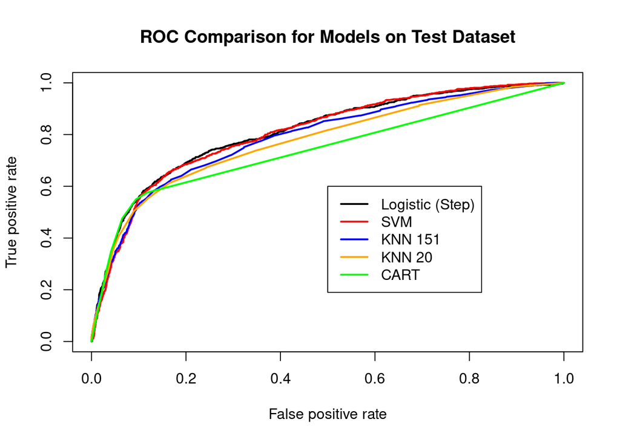

```r
### Plot our ROC Performance with Logit as base
plot(Logit.ROC, lwd=2, main = "ROC Comparison for Models on Test Dataset")

# Add SVM
lines(attributes(SVM.ROC)$x.values[[1]], attributes(SVM.ROC)$y.values[[1]],
      col="red", lwd=2)

# Add KNN
lines(attributes(KNN.ROC)$x.values[[1]], attributes(KNN.ROC)$y.values[[1]],
      col="blue", lwd=2)

lines(attributes(KNN.20.ROC)$x.values[[1]], attributes(KNN.20.ROC)$y.values[[1]],
      col="orange", lwd=2)

# Add CART
lines(attributes(CART.ROC)$x.values[[1]], attributes(CART.ROC)$y.values[[1]],
      col="green", lwd=2)

#Add Legend
legend(x=.5, y=.6, c("Logistic (Step)", "SVM", "KNN 151", "KNN 20", "CART"),
       col=c("black", "red", "blue","orange", "green"), lwd=c(2,2,2,2,2))
```

```r
Logit.AUC.na_omit
```

```
## [[1]]
## [1] 0.8109604
```

```r
SVM.AUC.na_omit
```

```
## [[1]]
## [1] 0.8062575
```

```r
KNN.AUC
```

```
## [[1]]
## [1] 0.7891984
```

```r
KNN.20.AUC
```

```
## [[1]]
## [1] 0.775382
```

```r
CART.AUC
```

```
## [[1]]
## [1] 0.7406039
```

Logit remains the best model thus far.

Submission Instructions

For this weekly lab assignment, you should submit:

An R script file (or Rmd file)

A written summary/discussion of your work (as discussed above) in .docx or .pdf format.

If you want to just summarize in a single Rmd file, please make sure you write your answer very clearly.

##Week 7 Take-Home Lab Assignment

Introduction

For this week’s take-home lab, you will work on the same data set from Week 4/5 Take-Home Labs. You will solve the very same problem studied in this week’s in-class lab on a much larger and more interesting dataset. The data contained in the file UCI_Credit_Card.csv contains 30,000 consumer records with 24 different variables. You can read a detailed description of the different fields at the following website: https://archive.ics.uci.edu/ml/datasets/default+of+credit+card+clients The description from the UCI says marriage should have levels: Marital status (1 = married; 2 = single; 3 = others) However, there are levels (0,1,2,3). You should treat 0 as unknown. the description from the UCI says Education (1 = graduate school; 2 = university; 3 = high school; 4 = others). However, there are levels 1 to 6 for education. Thus here 5 = 6 = unknown. X6-X11: The measurement scale for the repayment status is: -1 = pay duly; 1 = payment delay for one month; 2 = payment delay for two months; . . .; 8 = payment delay for eight months; 9 = payment delay for nine months and above. However, there are many factors that are -2. This is also unknown. So every unknown you should treat them as NA.

Your task is to build the best possible model for predicting whether or not a consumer will default on their credit card payment for the next month (the last column in the dataset). Assignment

Perform the following tasks:

Conduct a training/test split of the data, building a 20% held out test dataset

### RF Model

Fit the best RF model you can (consider feature selection etc.) to the data to predict consumer default.

```r
library(randomForest)

RandomForest <- randomForest(default.payment.next.month ~ ., data=na_omit.Train, importance = TRUE, ntrees = 500)
summary(RandomForest)
plot(RandomForest)
```

```r
# Get the probability of "yes" for default from second column
predProbRF <- predict(RandomForest, newdata = na_omit.Test, type = "prob")[,2]


# Get the predicted class
predClassRF <- predict(RandomForest, newdata = na_omit.Test, type = "response")
```

Then plot ROC curves for the logistic regression, SVM, KNN, CART, and RF models, and compare their performance.

```r
RF.ROC <- performance(prediction(predProbRF, na_omit.Test$default.payment.next.month),
                       measure="tpr", x.measure="fpr")
```

Compute the AUC for the logistic regression, SVM, KNN, CART, and RF models, and compare their performance.

```r
RF.AUC <- performance(prediction(predProbRF, na_omit.Test$default.payment.next.month),
                       measure="auc")@y.values
```

### Assignment Questions

Provide a summary and discussion of your work in written form (.docx or .pdf) that includes the following:

Q1 Summarize the model/feature selection process you used to fit your RF model.

I didn’t do anything fancy here, just let the package construct the model and compared it to my previous models.

Q2 Provide a summary of the fitted RF model (i.e. model summary)

```r
summary(RandomForest)
```

```
##                 Length Class  Mode
## call                5  -none- call
## type                1  -none- character
## predicted       18518  factor numeric
## err.rate         1500  -none- numeric
## confusion           6  -none- numeric
## votes           37036  matrix numeric
## oob.times       18518  -none- numeric
## classes             2  -none- character
## importance         92  -none- numeric
## importanceSD       69  -none- numeric
## localImportance     0  -none- NULL
## proximity           0  -none- NULL
## ntree               1  -none- numeric
## mtry                1  -none- numeric
## forest             14  -none- list
## y               18518  factor numeric
## test                0  -none- NULL
## inbag               0  -none- NULL
## terms               3  terms  call
```

Q3 Provide performance evaluation of the fitted RF model using confusion matrix.

```r
# Report confusion matrix from on the test dataset
confusionMatrix(predClassRF , na_omit.Test$default.payment.next.month)
```

```
## Confusion Matrix and Statistics
##
##           Reference
## Prediction   No  Yes
##        No  3343  586
##        Yes  228  473
##
##                Accuracy : 0.8242
##                  95% CI : (0.8129, 0.8351)
##     No Information Rate : 0.7713
##     P-Value [Acc > NIR] : < 2.2e-16
##
##                   Kappa : 0.4345
##
##  Mcnemar's Test P-Value : < 2.2e-16
##
##             Sensitivity : 0.9362
##             Specificity : 0.4466
##          Pos Pred Value : 0.8509
##          Neg Pred Value : 0.6748
##              Prevalence : 0.7713
##          Detection Rate : 0.7220
##    Detection Prevalence : 0.8486
##       Balanced Accuracy : 0.6914
##
##        'Positive' Class : No
##
```

The RF model does not predict as many people that actually default as the Logit model. (473 vs 512)

Q4 How well do you think the fitted RF model to this dataset works?

RF looks to do just about as well as Logit or SVM. More on the tradeoff below.

Q5 Using ROC curves and AUC, which one of logistic regression, SVM, KNN, CART, and RF models works better with the dataset over all?

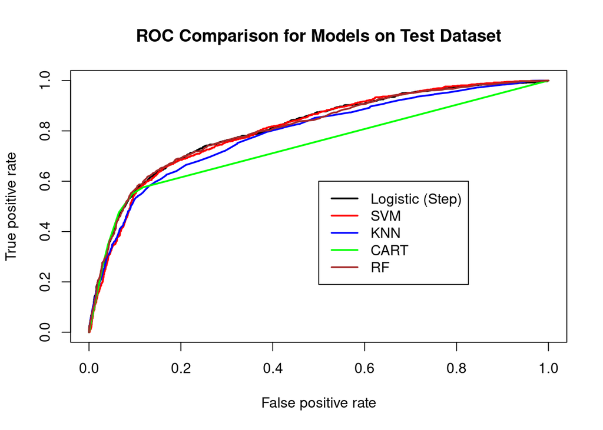

```r
### Plot our ROC Performance with Logit as base
plot(Logit.ROC, lwd=2, main = "ROC Comparison for Models on Test Dataset")

# Add SVM
lines(attributes(SVM.ROC)$x.values[[1]], attributes(SVM.ROC)$y.values[[1]],
      col="red", lwd=2)

# Add KNN
lines(attributes(KNN.ROC)$x.values[[1]], attributes(KNN.ROC)$y.values[[1]],
      col="blue", lwd=2)

# Add CART
lines(attributes(CART.ROC)$x.values[[1]], attributes(CART.ROC)$y.values[[1]],
      col="green", lwd=2)

# Add RF
lines(attributes(RF.ROC)$x.values[[1]], attributes(RF.ROC)$y.values[[1]],
      col="Brown", lwd=2)

#Add Legend
legend(x=.5, y=.6, c("Logistic (Step)", "SVM", "KNN", "CART", "RF"),
       col=c("black", "red", "blue", "green", "Brown"), lwd=c(2,2,2,2,2))
```

```r
Logit.AUC.na_omit
```

```
## [[1]]
## [1] 0.8109604
```

```r
SVM.AUC.na_omit
```

```
## [[1]]
## [1] 0.8062575
```

```r
KNN.AUC
```

```
## [[1]]
## [1] 0.7891984
```

```r
CART.AUC
```

```
## [[1]]
## [1] 0.7406039
```

```r
RF.AUC
```

```
## [[1]]
## [1] 0.8089697
```

As we can see, Logit remains in first place, but RF has taken over 2nd place in performance. It is also very efficient in terms of computation time, but is significantly less interpretable than our basic partition tree.

Submission Instructions

For this weekly lab assignment, you should submit:

```
An R script file (or Rmd file)

A written summary/discussion of your work (as discussed above) in .docx or .pdf format.
```

If you want to just summarize in a single Rmd file, please make sure you write your answer very clearly.

##Winter 24 Week 1 Take Home

### Assignment

Perform the following tasks:

- Conduct a training/test split of the data, building a 20% held out test dataset
- Update all your work from OA4106 incoorporating my comments (if there is any) for RF, logistic regression, KNN, CART, SVM models to the data to predict consumer default.
- Then you add ADABOOST from the “ada” package.

```r
library(ada)
```

- Then plot ROC curves for the logistic regression, SVM, KNN, CART, RF, adaboost models, and compare their performance.

```r
### Plot our ROC Performance with Logit as base
plot(Logit.ROC, lwd=2, main = "ROC Comparison for Models on Test Dataset")

# Add SVM
lines(attributes(SVM.ROC)$x.values[[1]], attributes(SVM.ROC)$y.values[[1]],
      col="red", lwd=2)

# Add KNN
lines(attributes(KNN.ROC)$x.values[[1]], attributes(KNN.ROC)$y.values[[1]],
      col="blue", lwd=2)

# Add CART
lines(attributes(CART.ROC)$x.values[[1]], attributes(CART.ROC)$y.values[[1]],
      col="green", lwd=2)

# Add RF
lines(attributes(RF.ROC)$x.values[[1]], attributes(RF.ROC)$y.values[[1]],
      col="Brown", lwd=2)

# Add adaboost

#Add Legend
legend(x=.5, y=.6, c("Logistic (Step)", "SVM", "KNN", "CART", "RF"),
       col=c("black", "red", "blue", "green", "Brown"), lwd=c(2,2,2,2,2))
```

- Compute the AUC for the logistic regression, SVM, KNN, CART, RF, adaboost models, and compare their performance.

```r
Logit.AUC.na_omit
SVM.AUC.na_omit
KNN.AUC
CART.AUC
RF.AUC
adaboost.AUC
```

[output not shown]

- Provide a summary and discussion of your work in written form (.docx or .pdf) that includes the following:
  - Q1 Summarize the model/feature selection process you used to fit your RF model
  - Q2 Provide a summary of the fitted ADABOOST model (i.e. model summary)
  - Q3 Provide performance evaluation of the fitted ADABOOST model using confusion matrix.
  - Q4 How well do you think the fitted ADABOOST model to this dataset works?
  - Q5 Using ROC curves and AUC, which one of logistic regression, SVM, KNN, CART, RF, and ADABOOST models works better with the dataset over all?

#### Submission Instructions

For this weekly lab assignment, you should submit:

- An R script file (or Rmd file)
- A written summary/discussion of your work (as discussed above) in .docx or .pdf format.

If you want to just summarize in a single Rmd file, please make sure you write your answer very clearly.